# Reading Data into R

#### Working Directory

To read data into R, we need to first set our *working directory*. The working directory is the location on our computer where are files we want to read into R are saved. Setting our working directory allows us to call a file by name, such as *file1.csv* rather than have the specify the exact location of the file, such as *C:/Place/Where/The/File/Is/Saved/file1.csv*.

To view our current working directory, we can use the following command:

```r
getwd()
```

The *wd* stands for working directory. If the output shows us the locoation on our computer where our files we want to read into R are saved, then we don’t need to do anything further.

However, if we need to change our working directory, we can do so by running the following command:

```r
setwd("C:/Place/Where/The/File/Is/Saved/")
```

Notice we need to use forward slashes rather than backward slashes.

A quick way to get the exact location of our working directory is to use your computer’s file explorer to go to the folder where your file is saved and copy the location. Here is a screenshot of an example from windows:

[figure not shown]

We can the paste this location into our setwd(“”) command. We would just need to change the backslahes used in Windows for forward slahes:

```r
setwd("C:/Users/HIV-Proteomics/Desktop/Matt/ProjectTutorials")
```

#### The read.csv() Function

Let’s suppose we have a .csv file we want to read into R, named *ExampleData.csv*. Here is what the data looks like:

```
##           V1                   V2        V3        V4        V5        V6
## 1            Dataset from study 1
## 2    Microbe            Subject 1 Subject 2 Subject 3 Subject 4 Subject 5
## 3  Microbe A                   63        45        80        71        56
## 4  Microbe B                   21        87        83        58        12
## 5  Microbe C                   22        56         8        31        50
## 6  Microbe D                   41        47        73        46        87
## 7  Microbe E                   29        96        60        39        79
## 8  Microbe F                   78         4        83        78        39
## 9  Microbe G                   78        70        73        77        67
## 10 Microbe H                   18        17        52        46        49
## 11 Microbe I                   17        82        56        13         9
## 12 Microbe J                   65        32        66        21        55
```

Let’s try reading this data into R using the *read.csv* function and save it to the object *data*:

```r
data <- read.csv("ExampleData.csv")
```

Here is what our data looks like inside of R:

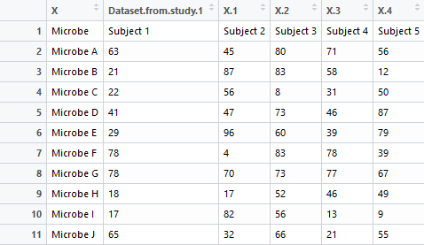

Clearly, this is not what we want. For starters, we have a line in the dataset that is just some extraneous information (“Dataset from study 1”) about the file and not anything we need.

Let’s use the *skip* argument to get rid of the first line:

```r
data <- read.csv("ExampleData.csv", skip = 1)
```

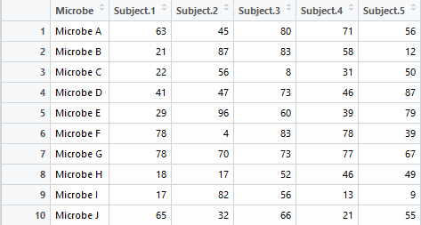

As we can see, adding *skip = 1* made the *read.csv* command skip the first line. Had we had 3 lines of our data we wanted to ignore, we would have used *skip = 3*.

Notice too that our list of microbes are in the first column of our data, rather than as row names as the number 1 through 10 are now.

The easiest way to make our variable of microbe names into actual row names is by specifying we want the *read.csv* to use the *row.names* argument to tell R we want to use our first variable as our row names:

```r
data <- read.csv("ExampleData.csv", skip = 1, row.names = 1)
```

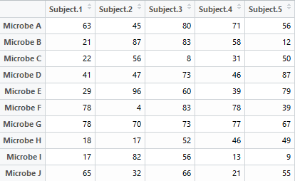

Had we wanted to use our third column as our row names, we would have used *row.names = 3*.

Now our data is read into R just the way we want, and is ready for further processing and analysis.

### Dealing with Missing Values

Many times there will be missing values in a dataset. To be concrete, let’s generate a dataset with some missing values:

```r
set.seed(1) #set random number generator
data <- matrix(round(runif(60, 1, 100), 3), 10, 6)
data[7, 2] <- NA; data[7, 3] <- NA; data[9, 6] <- NA
colnames(data) <- paste("Subject", 1:6)
rownames(data) <- paste("Microbe", 1:10)
```

Let’s have a look at the data the code above generated:

```r
data
```

```
##            Subject 1 Subject 2 Subject 3 Subject 4 Subject 5 Subject 6
## Microbe 1     27.285    21.391    93.536    48.726    82.274    48.284
## Microbe 2     37.840    18.479    22.002    60.357    65.059    86.260
## Microbe 3     57.712    69.015    65.516    49.861    78.510    44.372
## Microbe 4     90.913    39.026    13.430    19.436    55.751    25.235
## Microbe 5     20.967    77.214    27.455    82.910    53.442     7.997
## Microbe 6     89.941    50.272    39.225    67.178    79.146    10.847
## Microbe 7     94.523        NA        NA    79.630     3.310    32.311
## Microbe 8     66.419    99.199    38.856    11.686    48.246    52.345
## Microbe 9     63.282    38.623    87.099    72.647    73.499        NA
## Microbe 10     7.117    77.967    34.695    41.716    69.580    41.276
```

As we can see, we have three missing (*NA*) values – Subject 2 and 3 each have a missing value for Microbe 7, and Subject 6 has a missing value for Microbe 9.

#### Imputing Missing Values with 0s

There are many different ways to deal with these missing values. If we are going to calculate proportions and the only reason the value is missing is because a particular protein wasn’t identified for a subject, we can impute the missing values with 0s.

The *is.na()* function in R will tell us all the values in our matrix that are missing:

```r
is.na(data)
```

```
##            Subject 1 Subject 2 Subject 3 Subject 4 Subject 5 Subject 6
## Microbe 1      FALSE     FALSE     FALSE     FALSE     FALSE     FALSE
## Microbe 2      FALSE     FALSE     FALSE     FALSE     FALSE     FALSE
## Microbe 3      FALSE     FALSE     FALSE     FALSE     FALSE     FALSE
## Microbe 4      FALSE     FALSE     FALSE     FALSE     FALSE     FALSE
## Microbe 5      FALSE     FALSE     FALSE     FALSE     FALSE     FALSE
## Microbe 6      FALSE     FALSE     FALSE     FALSE     FALSE     FALSE
## Microbe 7      FALSE      TRUE      TRUE     FALSE     FALSE     FALSE
## Microbe 8      FALSE     FALSE     FALSE     FALSE     FALSE     FALSE
## Microbe 9      FALSE     FALSE     FALSE     FALSE     FALSE      TRUE
## Microbe 10     FALSE     FALSE     FALSE     FALSE     FALSE     FALSE
```

As we can see, there are three TRUE values corresponding to the missing values of our dataset. To impute these values with a zero we simply use this command:

```r
data[is.na(data)] <- 0
```

This changes all the missing values in our dataset to 0s. Let’s have a look:

```r
data
```

```
##            Subject 1 Subject 2 Subject 3 Subject 4 Subject 5 Subject 6
## Microbe 1     27.285    21.391    93.536    48.726    82.274    48.284
## Microbe 2     37.840    18.479    22.002    60.357    65.059    86.260
## Microbe 3     57.712    69.015    65.516    49.861    78.510    44.372
## Microbe 4     90.913    39.026    13.430    19.436    55.751    25.235
## Microbe 5     20.967    77.214    27.455    82.910    53.442     7.997
## Microbe 6     89.941    50.272    39.225    67.178    79.146    10.847
## Microbe 7     94.523     0.000     0.000    79.630     3.310    32.311
## Microbe 8     66.419    99.199    38.856    11.686    48.246    52.345
## Microbe 9     63.282    38.623    87.099    72.647    73.499     0.000
## Microbe 10     7.117    77.967    34.695    41.716    69.580    41.276
```

#### Removing Incomplete Observations

Another option to deal with missing values is to remove any observation (row) in a dataset that has a missing value. We can use the *complete.cases()* function similar to how we did with the *is.na()* function above to see which observations (rows) in our dataset are complete:

```r
data[complete.cases(data), ]
```

[output not shown]

#### Questions or comments

If you have any further questions, or comments, you can contact Matt Cook (cookm346@myumanitoba.ca).